# Univariate Plots Section

# Univariate Analysis

### What is the structure of your dataset?

There are 1599 observations with 13 variables where x is the identifier.

```
##  [1] "X"                    "fixed.acidity"        "volatile.acidity"
##  [4] "citric.acid"          "residual.sugar"       "chlorides"
##  [7] "free.sulfur.dioxide"  "total.sulfur.dioxide" "density"
## [10] "pH"                   "sulphates"            "alcohol"
## [13] "quality"
```

### What is/are the main feature(s) of interest in your dataset?

The main feature is the quality. I would like to see which of the other variables have the biggest influence on the quality.

### What other features in the dataset do you think will help support your investigation into your feature(s) of interest?

I plan to investigate the variables that have an impact on taste or aroma of the wine. These are the factors that determine the quality:

- Volatile acidity - high levels result in a vinegar like taste
- Citric acid - What is the right level of citric acid for a high quality wine
- Alcohol - the level of alcohol and the effect on quality aroma.

### Did you create any new variables from existing variables in the dataset?

- Quality_factor = converted quality to factor

### Of the features you investigated, were there any unusual distributions? Did you perform any operations on the data to tidy, adjust, or change the form of the data? If so, why did you do this?

No unusual distributions. No data cleaning performed

# Bivariate Plots Section

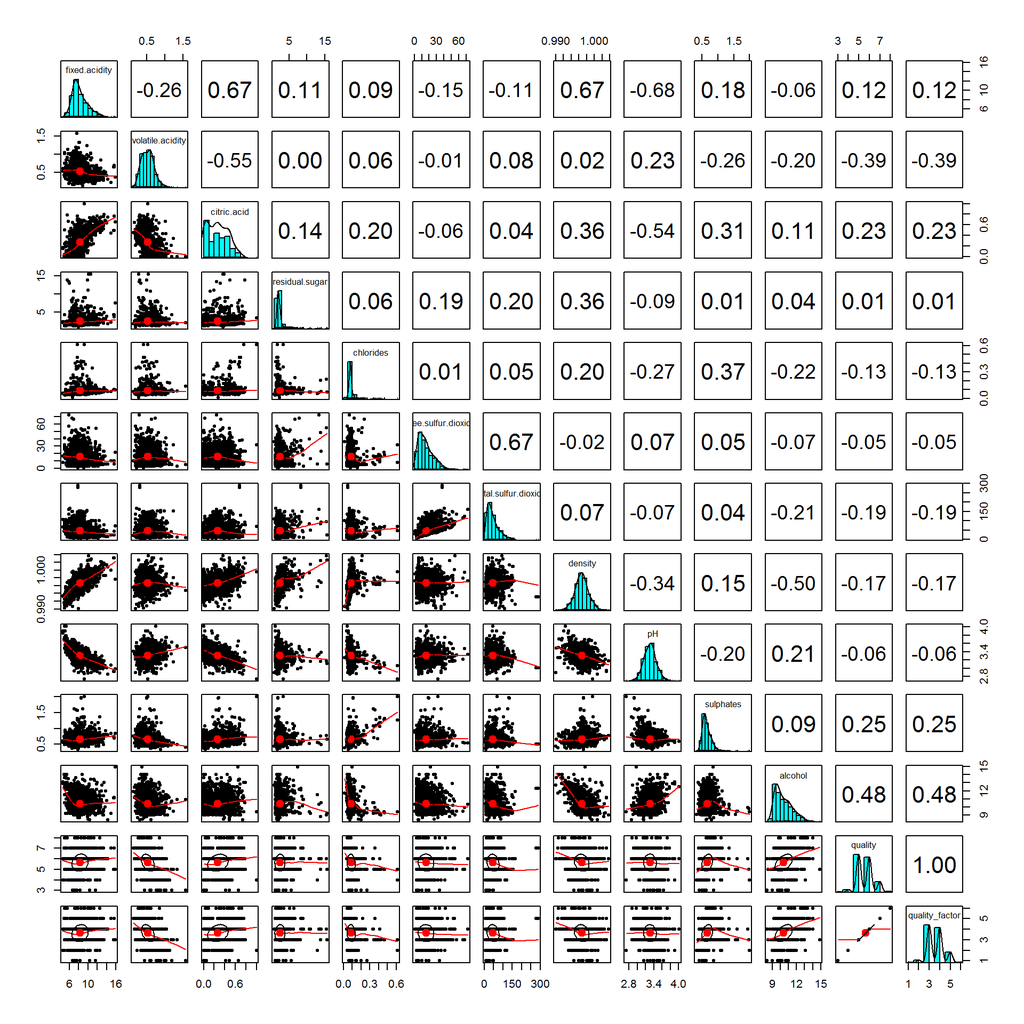

```
##                      fixed.acidity volatile.acidity citric.acid
## fixed.acidity           1.00000000     -0.256130895  0.67170343
## volatile.acidity       -0.25613089      1.000000000 -0.55249568
## citric.acid             0.67170343     -0.552495685  1.00000000
## residual.sugar          0.11477672      0.001917882  0.14357716
## chlorides               0.09370519      0.061297772  0.20382291
## free.sulfur.dioxide    -0.15379419     -0.010503827 -0.06097813
## total.sulfur.dioxide   -0.11318144      0.076470005  0.03553302
## density                 0.66804729      0.022026232  0.36494718
## pH                     -0.68297819      0.234937294 -0.54190414
## sulphates               0.18300566     -0.260986685  0.31277004
## alcohol                -0.06166827     -0.202288027  0.10990325
## quality                 0.12405165     -0.390557780  0.22637251
##                      residual.sugar    chlorides free.sulfur.dioxide
## fixed.acidity           0.114776724  0.093705186        -0.153794193
## volatile.acidity        0.001917882  0.061297772        -0.010503827
## citric.acid             0.143577162  0.203822914        -0.060978129
## residual.sugar          1.000000000  0.055609535         0.187048995
## chlorides               0.055609535  1.000000000         0.005562147
## free.sulfur.dioxide     0.187048995  0.005562147         1.000000000
## total.sulfur.dioxide    0.203027882  0.047400468         0.667666450
## density                 0.355283371  0.200632327        -0.021945831
## pH                     -0.085652422 -0.265026131         0.070377499
## sulphates               0.005527121  0.371260481         0.051657572
## alcohol                 0.042075437 -0.221140545        -0.069408354
## quality                 0.013731637 -0.128906560        -0.050656057
##                      total.sulfur.dioxide     density          pH
## fixed.acidity                 -0.11318144  0.66804729 -0.68297819
## volatile.acidity               0.07647000  0.02202623  0.23493729
## citric.acid                    0.03553302  0.36494718 -0.54190414
## residual.sugar                 0.20302788  0.35528337 -0.08565242
## chlorides                      0.04740047  0.20063233 -0.26502613
## free.sulfur.dioxide            0.66766645 -0.02194583  0.07037750
## total.sulfur.dioxide           1.00000000  0.07126948 -0.06649456
## density                        0.07126948  1.00000000 -0.34169933
## pH                            -0.06649456 -0.34169933  1.00000000
## sulphates                      0.04294684  0.14850641 -0.19664760
## alcohol                       -0.20565394 -0.49617977  0.20563251
## quality                       -0.18510029 -0.17491923 -0.05773139
##                         sulphates     alcohol     quality
## fixed.acidity         0.183005664 -0.06166827  0.12405165
## volatile.acidity     -0.260986685 -0.20228803 -0.39055778
## citric.acid           0.312770044  0.10990325  0.22637251
## residual.sugar        0.005527121  0.04207544  0.01373164
## chlorides             0.371260481 -0.22114054 -0.12890656
## free.sulfur.dioxide   0.051657572 -0.06940835 -0.05065606
## total.sulfur.dioxide  0.042946836 -0.20565394 -0.18510029
## density               0.148506412 -0.49617977 -0.17491923
## pH                   -0.196647602  0.20563251 -0.05773139
## sulphates             1.000000000  0.09359475  0.25139708
## alcohol               0.093594750  1.00000000  0.47616632
## quality               0.251397079  0.47616632  1.00000000
```

I am very surprised that there aren’t 2 variables with high corelation. There are clearly some variables that are corelated, such as pH and fixed acidity/volatile acidity/citric acid. I assumed that there would be a much higher level of corelation between these.

I will start with the variables that have meaningful corelations to quality starting with the highest.

### Quality

This is my main feature of interest, I want to explore how different variables effect quality.

**Alcohol and quality** had a correlation value of 0.4761663

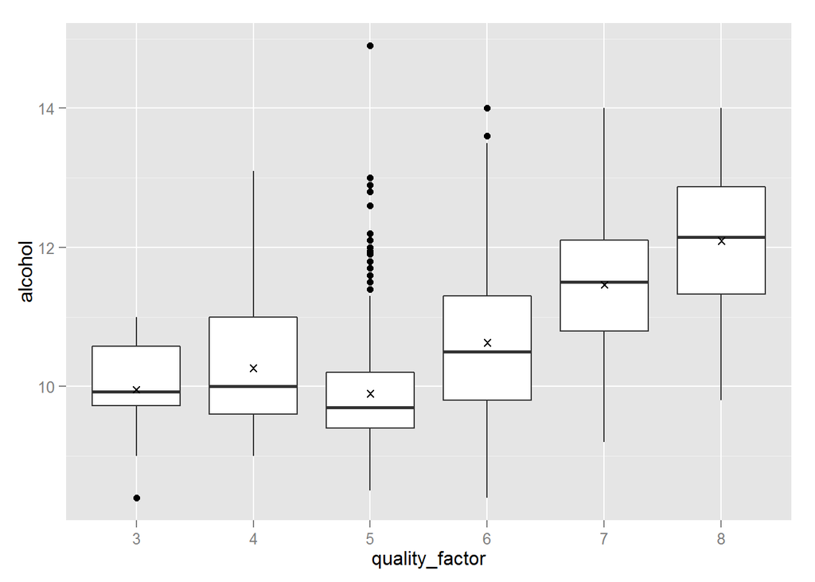

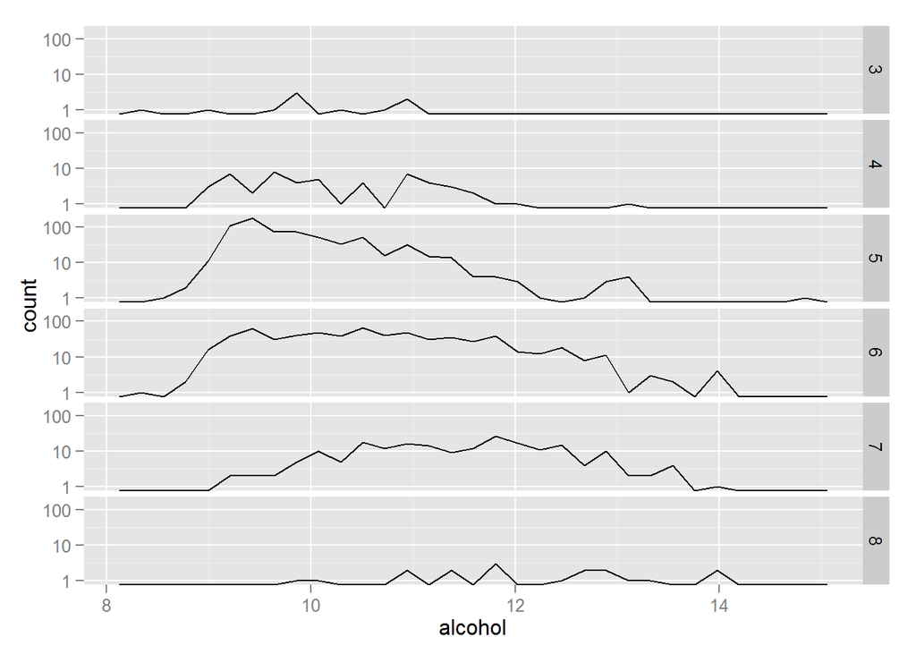

```
## Alcohol grouped by Quality
```

```
## $`3`
##    Min. 1st Qu.  Median    Mean 3rd Qu.    Max.
##   8.400   9.725   9.925   9.955  10.580  11.000
##
## $`4`
##    Min. 1st Qu.  Median    Mean 3rd Qu.    Max.
##    9.00    9.60   10.00   10.27   11.00   13.10
##
## $`5`
##    Min. 1st Qu.  Median    Mean 3rd Qu.    Max.
##     8.5     9.4     9.7     9.9    10.2    14.9
##
## $`6`
##    Min. 1st Qu.  Median    Mean 3rd Qu.    Max.
##    8.40    9.80   10.50   10.63   11.30   14.00
##
## $`7`
##    Min. 1st Qu.  Median    Mean 3rd Qu.    Max.
##    9.20   10.80   11.50   11.47   12.10   14.00
##
## $`8`
##    Min. 1st Qu.  Median    Mean 3rd Qu.    Max.
##    9.80   11.32   12.15   12.09   12.88   14.00
```

Since the scatterplot was overplotted I created a boxplot to better understand the relationship.

Because of the large difference in the number of wines in each quality group, I did a log10 transformation on the y axis so that I can see and compare the distribution between the groups.

Where quality is >= 6 the median, median, mean and quartiles all increase with the quality

When looking at the distribution of alochol content within each quality rating there are not enough wines in ratings 3,4 and 8 to see any patterns. But, for qualities 5,6,7 I can see that the distribution is becoming progressively less right skewed. Also, the wines that are rated higher (6 or above) have greater median alcohol levels.

These plots illustrate that **higher quality wines tend to have higher levels of alcohol**.

Next, I wanted to take a look at the relationship between **volatile acidity and quality** which had a correlation value of -0.3905578

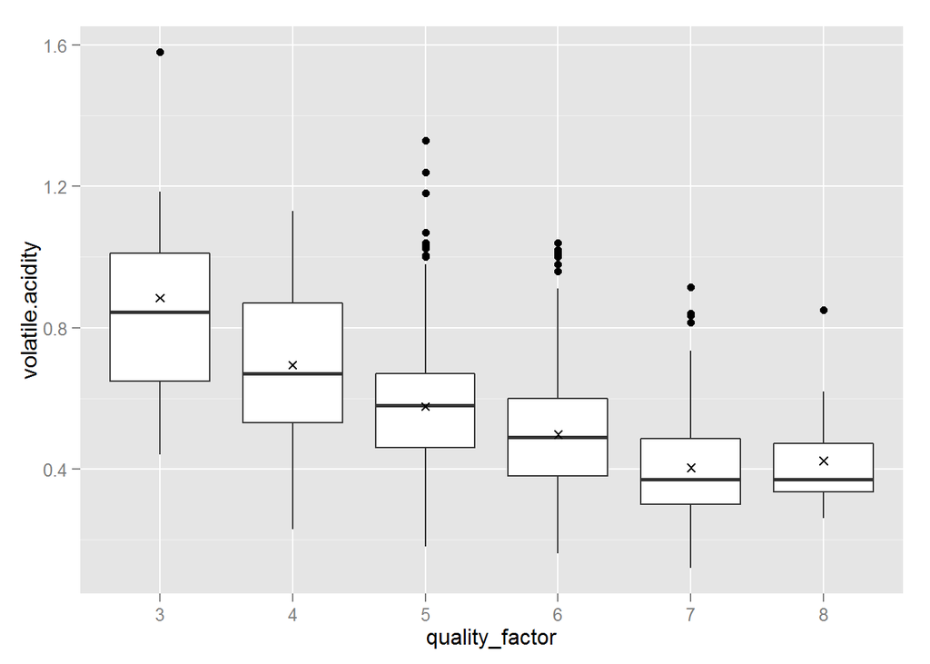

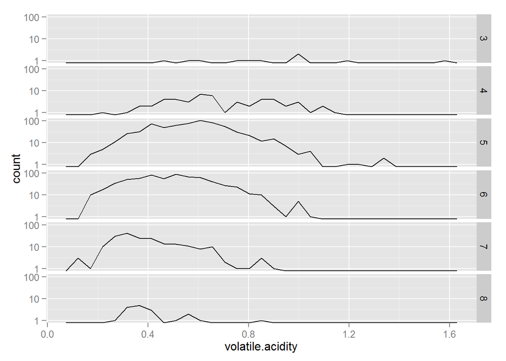

```
## Volatile acidity grouped by Quality
```

```
## $`3`
##    Min. 1st Qu.  Median    Mean 3rd Qu.    Max.
##  0.4400  0.6475  0.8450  0.8845  1.0100  1.5800
##
## $`4`
##    Min. 1st Qu.  Median    Mean 3rd Qu.    Max.
##   0.230   0.530   0.670   0.694   0.870   1.130
##
## $`5`
##    Min. 1st Qu.  Median    Mean 3rd Qu.    Max.
##   0.180   0.460   0.580   0.577   0.670   1.330
##
## $`6`
##    Min. 1st Qu.  Median    Mean 3rd Qu.    Max.
##  0.1600  0.3800  0.4900  0.4975  0.6000  1.0400
##
## $`7`
##    Min. 1st Qu.  Median    Mean 3rd Qu.    Max.
##  0.1200  0.3000  0.3700  0.4039  0.4850  0.9150
##
## $`8`
##    Min. 1st Qu.  Median    Mean 3rd Qu.    Max.
##  0.2600  0.3350  0.3700  0.4233  0.4725  0.8500
```

I am starting to notice that any plot that includes quality_factor is overplotted due to the discrete values and the continuous nature of other variables.Again, a box plot was used here due to overplotting.

Looking at the box plot, I can see that **higher quality levels have lower and much smaller variances of volatile acidity**. THe median level of volatile acidity decreases as quality increases with the exception of 8 which has very similiar levels to 7.

This is further confirmed by the distibution curves of volatile acid across each quality.

There is a relationship between **sulphates and quality** with a correlation value of 0.2513971.

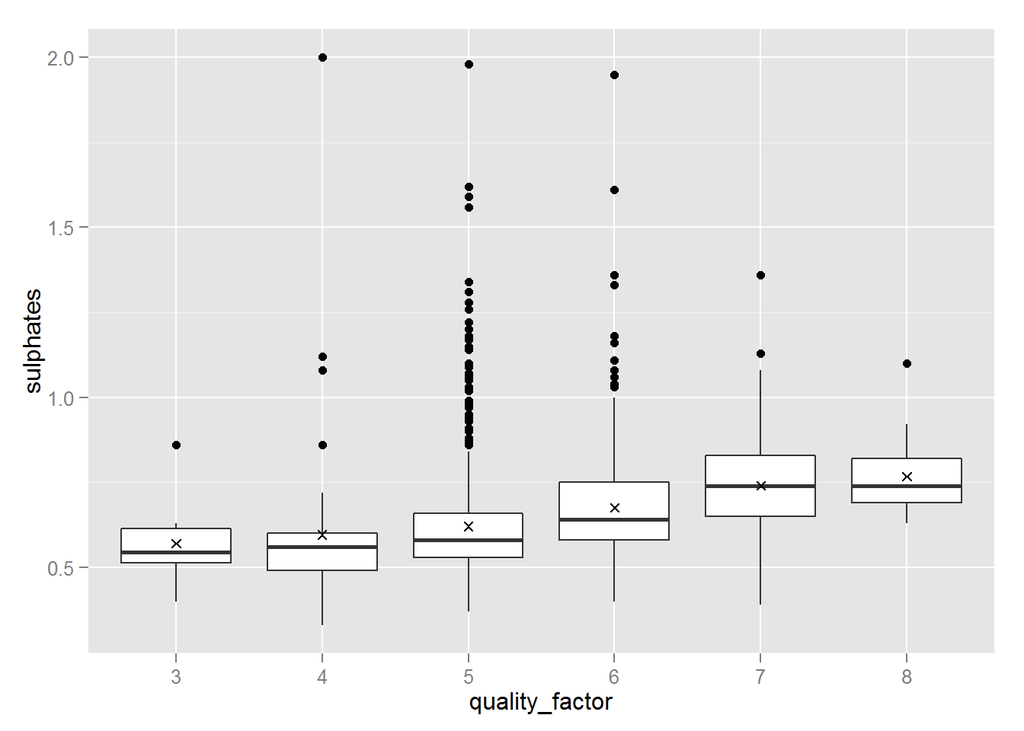

```
## Sulphates grouped by Quality
```

```
## $`3`
##    Min. 1st Qu.  Median    Mean 3rd Qu.    Max.
##  0.4000  0.5125  0.5450  0.5700  0.6150  0.8600
##
## $`4`
##    Min. 1st Qu.  Median    Mean 3rd Qu.    Max.
##  0.3300  0.4900  0.5600  0.5964  0.6000  2.0000
##
## $`5`
##    Min. 1st Qu.  Median    Mean 3rd Qu.    Max.
##   0.370   0.530   0.580   0.621   0.660   1.980
##
## $`6`
##    Min. 1st Qu.  Median    Mean 3rd Qu.    Max.
##  0.4000  0.5800  0.6400  0.6753  0.7500  1.9500
##
## $`7`
##    Min. 1st Qu.  Median    Mean 3rd Qu.    Max.
##  0.3900  0.6500  0.7400  0.7413  0.8300  1.3600
##
## $`8`
##    Min. 1st Qu.  Median    Mean 3rd Qu.    Max.
##  0.6300  0.6900  0.7400  0.7678  0.8200  1.1000
```

Higher quality wines have a higher levels of sulphate. For qualities >= 4 the median sulphate level increases with the quality.

### Density

As I mentioned earlier I don’t really have a good understanding of what density is. I want to have a look at some plots with variables that are correlated with density to get a better understanding.

First I want to see how **alcohol effects density**. These 2 variables have a correlation value of -0.4961798

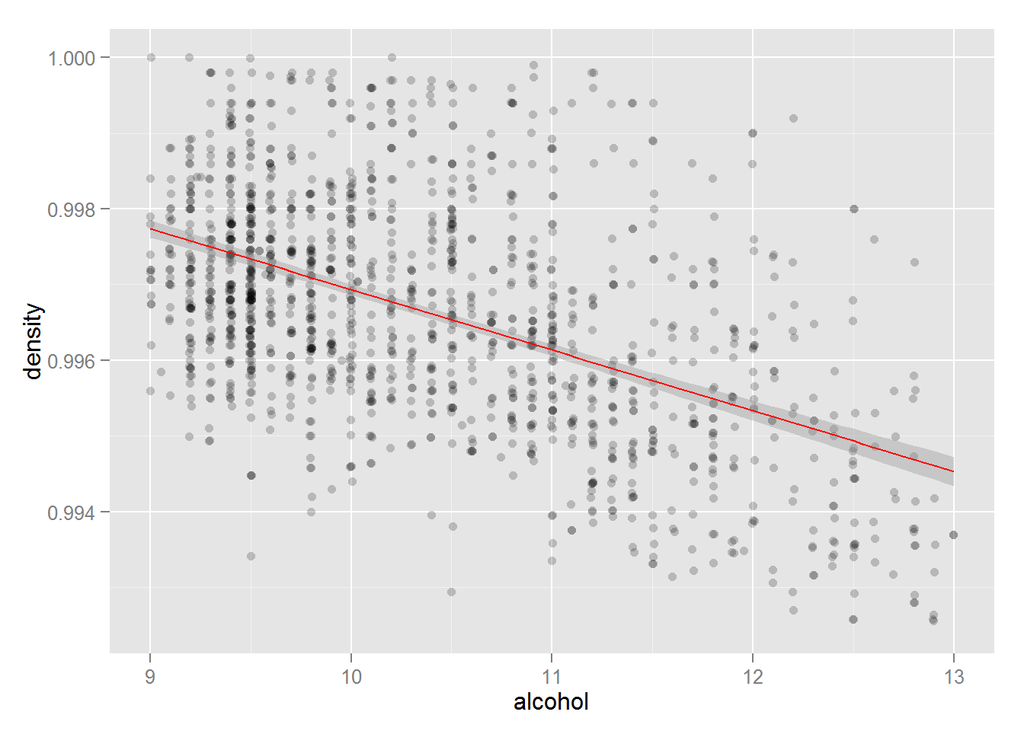

```
## Alcohol grouped by density quartiles
```

```
## $`(0.99,0.996]`
##    Min. 1st Qu.  Median    Mean 3rd Qu.    Max.
##    9.00   10.70   11.40   11.39   12.20   14.00
##
## $`(0.996,0.997]`
##    Min. 1st Qu.  Median    Mean 3rd Qu.    Max.
##    8.70    9.50   10.10   10.27   10.90   13.20
##
## $`(0.997,0.998]`
##    Min. 1st Qu.  Median    Mean 3rd Qu.    Max.
##   9.000   9.400   9.700   9.973  10.400  14.900
##
## $`(0.998,1]`
##    Min. 1st Qu.  Median    Mean 3rd Qu.    Max.
##    8.40    9.40    9.90   10.03   10.50   13.40
```

I removed some outliers by limiting the x and y axis to get a better view of the linear relationship.

The **lower the density the higher the alcohol content**. There is a general trend downwards where the density decreases as the level of alcohol increases but there is a high level of standard error. This could be because other variables also have an effect on density.

The next few plots, I will look at the variables that also have a high correlation value with density.

**Fixed acidity and density** have a correlation value of 0.6680473. Citric acid and density have a correlation value of 0.3649472

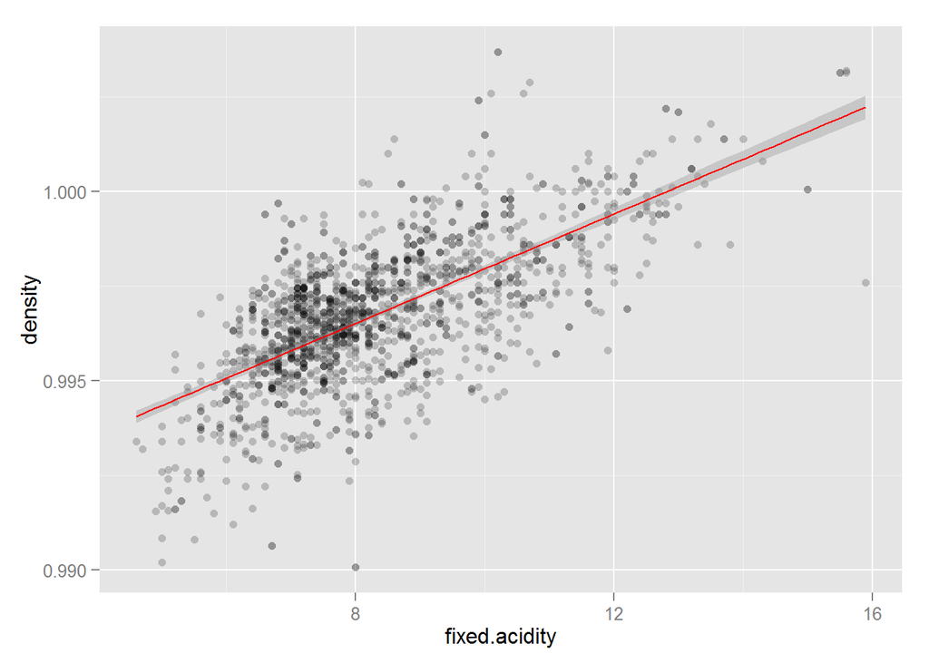

```
## Fixed acid grouped by density quartiles
```

```
## $`(0.99,0.996]`
##    Min. 1st Qu.  Median    Mean 3rd Qu.    Max.
##   4.600   6.400   7.000   7.124   7.800  10.800
##
## $`(0.996,0.997]`
##    Min. 1st Qu.  Median    Mean 3rd Qu.    Max.
##   5.200   7.100   7.600   7.789   8.200  11.900
##
## $`(0.997,0.998]`
##    Min. 1st Qu.  Median    Mean 3rd Qu.    Max.
##   5.600   7.300   8.000   8.345   9.100  15.900
##
## $`(0.998,1]`
##    Min. 1st Qu.  Median    Mean 3rd Qu.    Max.
##    6.60    8.80    9.90   10.03   11.40   15.60
```

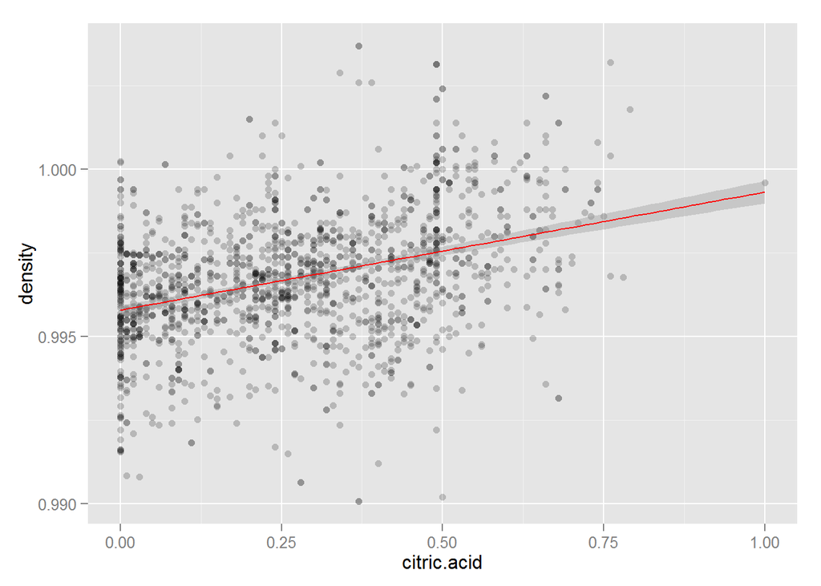

```
## Citric acid grouped by density quartiles
```

```
## $`(0.99,0.996]`
##    Min. 1st Qu.  Median    Mean 3rd Qu.    Max.
##  0.0000  0.0300  0.1700  0.2013  0.3500  0.6800
##
## $`(0.996,0.997]`
##    Min. 1st Qu.  Median    Mean 3rd Qu.    Max.
##  0.0000  0.0700  0.2100  0.2161  0.3200  0.6900
##
## $`(0.997,0.998]`
##    Min. 1st Qu.  Median    Mean 3rd Qu.    Max.
##  0.0000  0.1200  0.2800  0.2794  0.4225  0.7800
##
## $`(0.998,1]`
##    Min. 1st Qu.  Median    Mean 3rd Qu.    Max.
##  0.0000  0.2400  0.4100  0.3870  0.5125  1.0000
```

**Density increases as either fixed or citric acidity increases**. This is also the case in the median values for each density group where the citric acid and fixed acid levels increase as density increases.

**Residual sugar and density** have a correlation value of 0.3552834

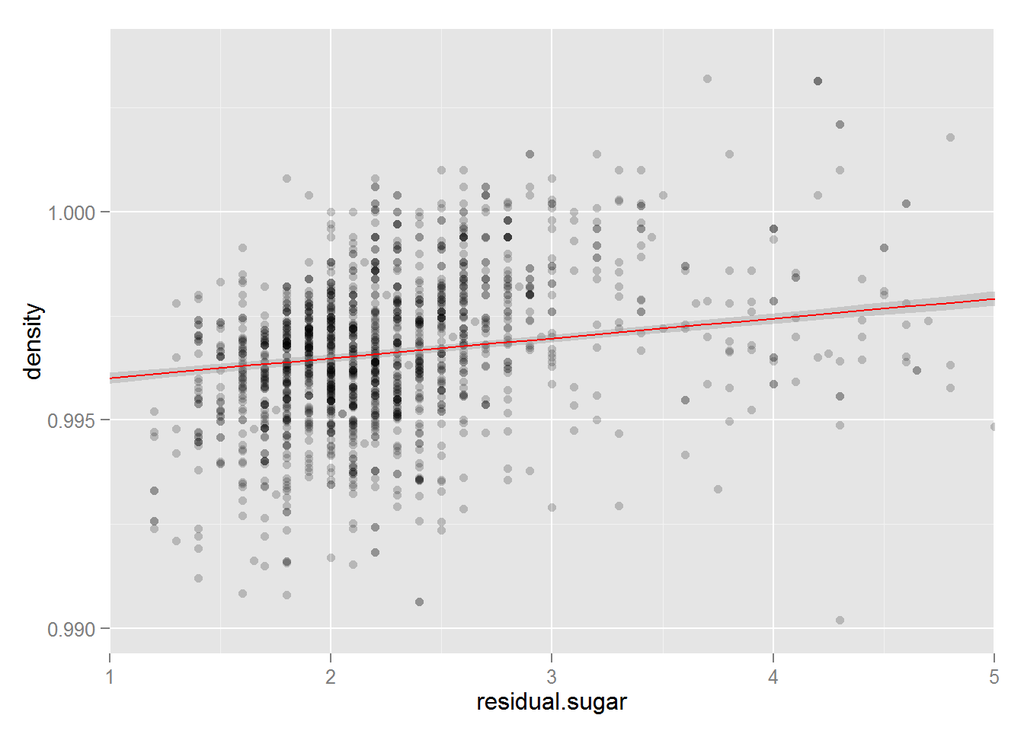

```
## Residual sugar grouped by density quartiles
```

```
## $`(0.99,0.996]`
##    Min. 1st Qu.  Median    Mean 3rd Qu.    Max.
##   1.200   1.800   2.000   2.135   2.300   8.600
##
## $`(0.996,0.997]`
##    Min. 1st Qu.  Median    Mean 3rd Qu.    Max.
##   1.300   1.875   2.100   2.312   2.400  12.900
##
## $`(0.997,0.998]`
##    Min. 1st Qu.  Median    Mean 3rd Qu.    Max.
##    1.30    1.90    2.10    2.46    2.50   13.90
##
## $`(0.998,1]`
##    Min. 1st Qu.  Median    Mean 3rd Qu.    Max.
##   1.400   2.300   2.600   3.258   3.225  15.500
```

Most of the plots are around residual sugar 1-5, it is a bit hard to see patterns because of the small number of outliers outside of this area. So, I limited the X axis to remove them.

As the amount of **residual sugar increases, the density generally increases**. This is supported by the summary statistics for each bucket of sugar values (based on quartile).

The vertical stripes indicate a degree of discreteness in the measurement if residual sugar. The precision of residual sugar is likely to be 1 decimal place, heres a sample:

```
##  [1] 1.9 2.6 2.3 1.9 1.9 1.8 1.6 1.2 2.0 6.1
```

### Acids

I want to take a closer look at the relationships between the various acids are, some of them exhibit high corellations.

**Volatile acidity and citric acid** have a correlation value of -0.5524957

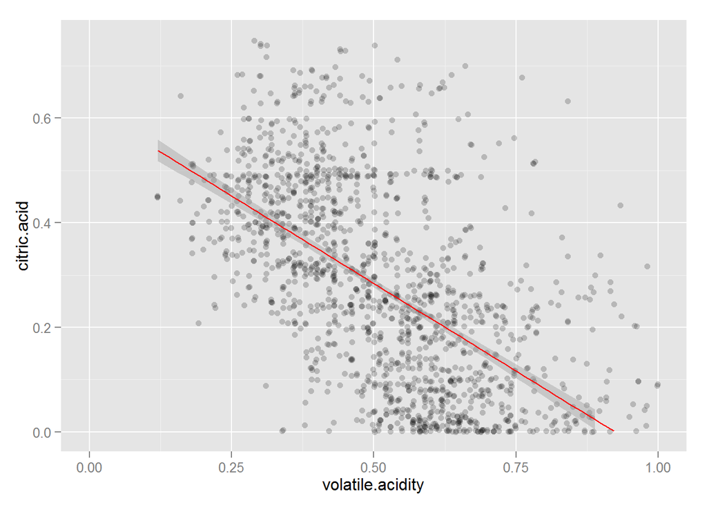

```
## Citric acid grouped by volatile acidity quartiles
```

```
## $`(0.12,0.39]`
##    Min. 1st Qu.  Median    Mean 3rd Qu.    Max.
##  0.0000  0.3400  0.4300  0.4263  0.5000  0.7800
##
## $`(0.39,0.52]`
##    Min. 1st Qu.  Median    Mean 3rd Qu.    Max.
##  0.0000  0.2000  0.3100  0.3233  0.4600  1.0000
##
## $`(0.52,0.64]`
##    Min. 1st Qu.  Median    Mean 3rd Qu.    Max.
##   0.000   0.050   0.170   0.188   0.260   0.790
##
## $`(0.64,1.58]`
##    Min. 1st Qu.  Median    Mean 3rd Qu.    Max.
##  0.0000  0.0200  0.0900  0.1358  0.2200  0.7600
```

There were some outliers with high citric acid and/or volatile acid which were removed to aid in analysing the data. **Citric acid decreases as volatile acidity increases**.

**Citric acid and fixed acidity** have a correlation of 0.6717034.

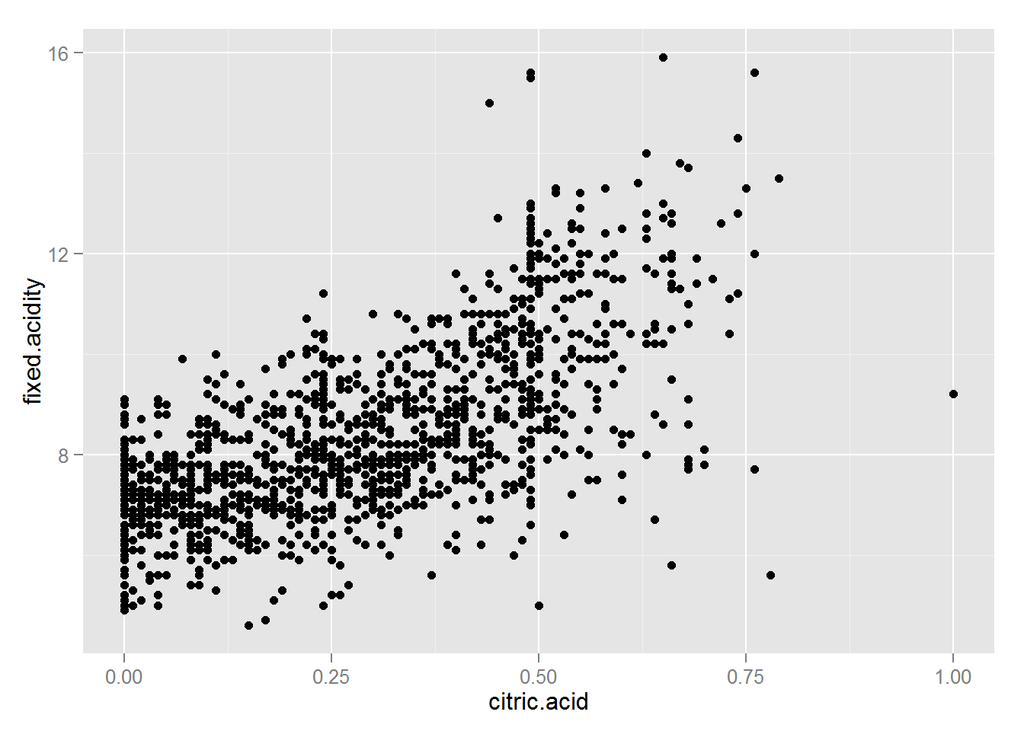

```
## Citric acid grouped by fixed acidity quartiles
```

```
## $`(4.6,7.1]`
##    Min. 1st Qu.  Median    Mean 3rd Qu.    Max.
##  0.0000  0.0200  0.0850  0.1271  0.2100  0.7800
##
## $`(7.1,7.9]`
##    Min. 1st Qu.  Median    Mean 3rd Qu.    Max.
##  0.0000  0.0600  0.2000  0.2026  0.3100  0.7600
##
## $`(7.9,9.2]`
##    Min. 1st Qu.  Median    Mean 3rd Qu.    Max.
##  0.0000  0.1900  0.3000  0.2966  0.4000  1.0000
##
## $`(9.2,15.9]`
##    Min. 1st Qu.  Median    Mean 3rd Qu.    Max.
##  0.0700  0.3900  0.4800  0.4666  0.5425  0.7900
```

How would changes in levels of these effect pH? Does one type of acid increase the pH level more than the other? **Citric/fixed acid and pH** have correlation values of -0.5419041 and -0.6829782 respectively.

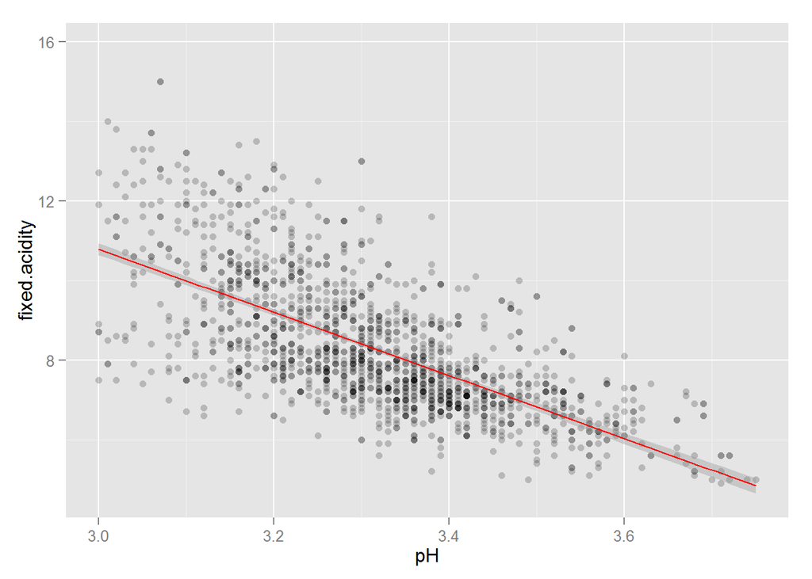

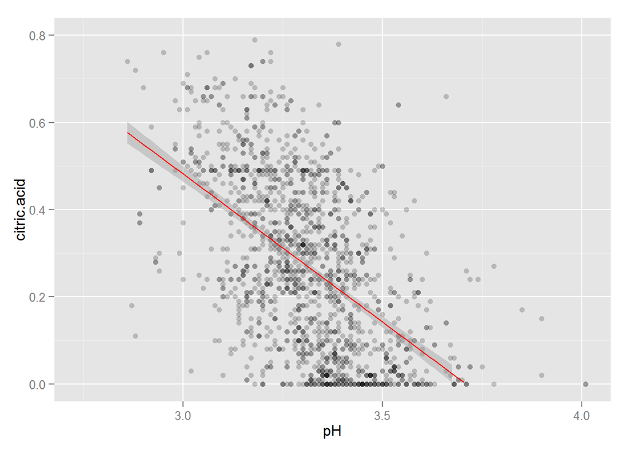

```
## Citric acid grouped by pH quartiles
```

```
## $`(2.74,3.21]`
##    Min. 1st Qu.  Median    Mean 3rd Qu.    Max.
##  0.0000  0.2500  0.4400  0.4071  0.5300  0.7900
##
## $`(3.21,3.31]`
##    Min. 1st Qu.  Median    Mean 3rd Qu.    Max.
##  0.0000  0.2100  0.3100  0.3074  0.4100  0.7600
##
## $`(3.31,3.4]`
##    Min. 1st Qu.  Median    Mean 3rd Qu.    Max.
##  0.0000  0.0600  0.2100  0.2178  0.3500  0.7800
##
## $`(3.4,4.01]`
##    Min. 1st Qu.  Median    Mean 3rd Qu.    Max.
##  0.0000  0.0150  0.0900  0.1363  0.2400  0.6600
```

As **pH level becomes more basic as the level of fixed or citric acidity decreases**. This one is expected since these pH is a measure of acidity.

Citric acid and pH has a much steeper trend line, this suggest that citric acid has a higher effect on pH than fixed acidity. But, as we saw earlier the level of citric acid is correlated to fixed acid so as the level of citiric acid increases so does the fixed acidity. Since fixed acidity is much more abundant, it should have a larger effect on pH.

I am still not satisfied that I understand the reason for the relationship between citric and fixed acidity. Accordng to wikipedia both fixed and citric acidity are naturally occuring in grapes and typically, citric acid levels are 1/20 those of fixed acidity.

So, I am going to have a look at the ratios of citric acid to fixed acidity to see what ratios the wines in the sample have.

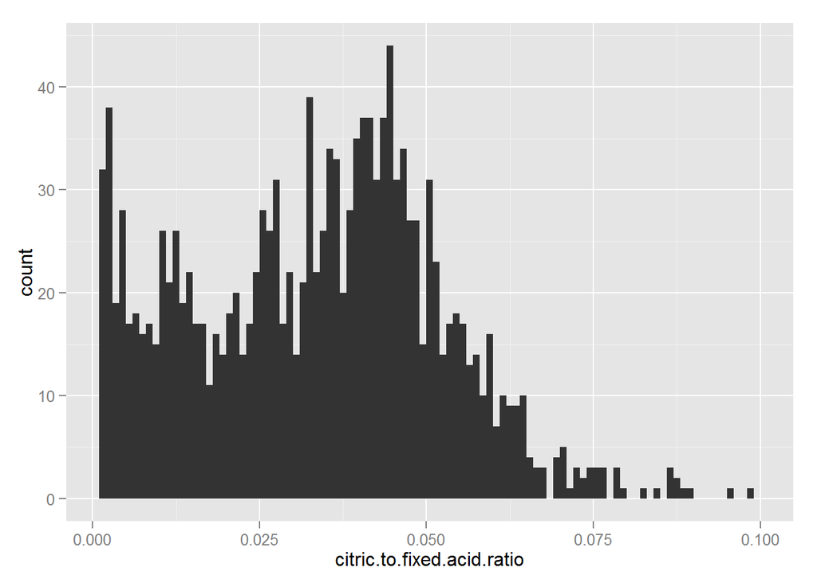

There were a significant number of wines with a ratio less than 0.001. This was making it difficult to look at the rest of the data, so i removed those plots. The ratio is generally less than 0.05 which is consistent with the wikipedia article.

### Sulfure Dioxide

The defintions suggest that Free and total sulfur dioxide seem to be related where the total also includes the free ammounts. These 2 variables have a coefficent value of 0.6676665

I want to see how they are related and how free SO2 increases as the total SO2 increases.

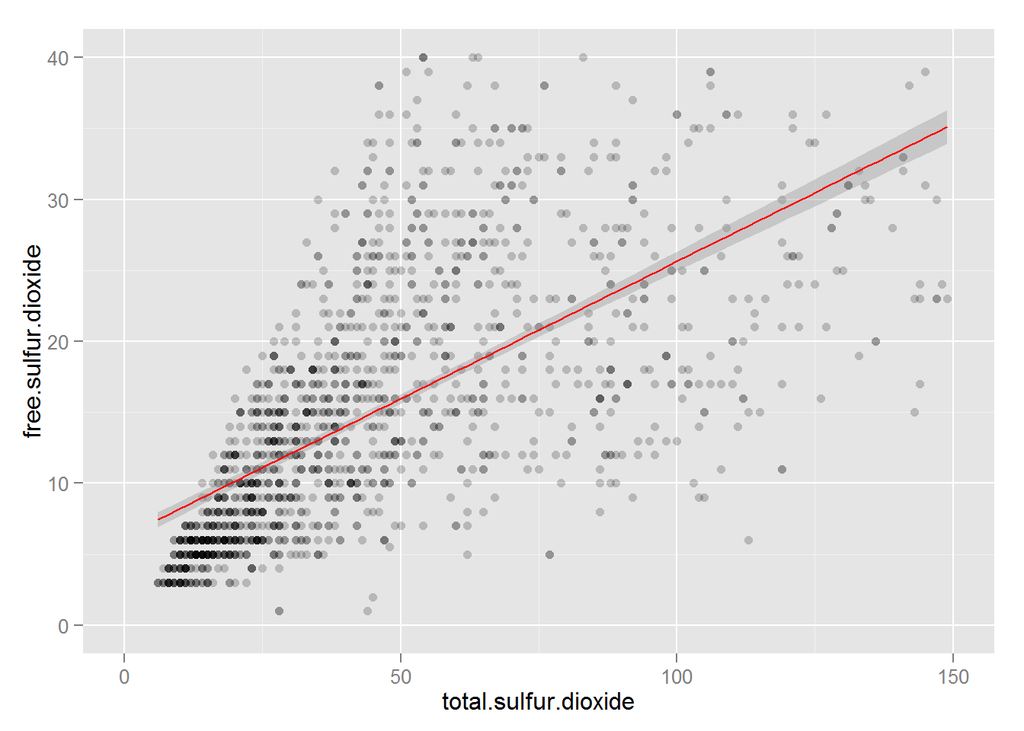

```
## Free sulphure dioxide grouped by total sulphur dioxide buckets
```

```
## $`(6,22]`
##    Min. 1st Qu.  Median    Mean 3rd Qu.    Max.
##   3.000   5.000   6.000   6.427   8.000  18.000
##
## $`(22,38]`
##    Min. 1st Qu.  Median    Mean 3rd Qu.    Max.
##    1.00    9.00   12.00   12.34   15.00   32.00
##
## $`(38,62]`
##    Min. 1st Qu.  Median    Mean 3rd Qu.    Max.
##    1.00   13.00   19.00   19.98   26.00   48.00
##
## $`(62,289]`
##    Min. 1st Qu.  Median    Mean 3rd Qu.    Max.
##    5.00   17.00   24.00   25.48   32.00   72.00
```

I want to see what the distribution of the ratios between them to understand the relationship better.

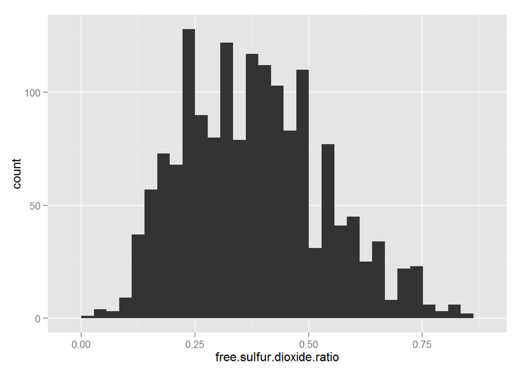

Most wines tend to have ratios between 0.25 to 0.5 of free to total SO2.

# Bivariate Analysis

### Talk about some of the relationships you observed in this part of the investigation. How did the feature(s) of interest vary with other features in the dataset?

- Higher quality wines have higher alcohol levels.
- Higher quality wines have lower volatile acidity.
- Higher quality wines have higher levels of sulphate.

### Did you observe any interesting relationships between the other features (not the main feature(s) of interest)?

- The higher the total SO2, the higher the level of free SO2. This is expected since sulphates can contribute to free SO2 levels.
- Lower levels of Citric acid mean more basic pH.

#### Density and Acids, Alcohol and Sugar

I saw some interested relationships between acids, alcohol and sugar with density. Acids and sugar increased density while alochol decreased it. I could not explain why this is by looking at the data provided. So, I did a bit of research. It turns out that different substances have different density values with water having a value of 0.99997 g / cm3 so depending on what other substances are present in the wine it will affect the density in different ways. This means that the density of wine is actually the thickness of the liquid.

Sugar and acids have a higher density than water, so increased levels of these will increase density. Alcohol has a lower density than water so an increaed amount of this will lower the density.

#### Volatile Acidity and Citric Acid

Higher volatile acidity have lower levels of citric acid. Perhaps, wine makings deliberately reduce the citric acid content of wine to avoid it tasting too sour when there are high levels of volatile acidity present. We will investigate this point further in the next section by adding quality into the plot.

### What was the strongest relationship you found?

- Quality and Alcohol
- Quality and volatile acidity
- Total SO2 and free SO2
- Fixed acidity and pH
- Fixed acidity and citric acid